# IDS investigation worksheet

by R-Squared: Aarnav , Patric , Miguel

2026-11-27

**Note:** You can use this file as you ‘working document’ where you can try out various investigation ideas and keep notes about your findings. How you use and structure this file is up to you. It is recommended that you keep notes about what you are investigating and what you find as this will make the process of creating your presentation and report easier. Please note that you *do not* need to submit this file as part of your group project.

```r
library(tidyverse)
# Add any other libraries here
```

```r
# load your data
load("~/IDS_R-Squared_Project/data/ames.rda")
```

```r
# clean your data
Filtered_ames <- ames %>%
  #removing columns with little data and irrelevant or extra data
  select(!c(
             Bsmt.Exposure ,
             BsmtFin.Type.1 ,
             BsmtFin.SF.1 ,
             BsmtFin.Type.2 ,
             BsmtFin.SF.2 ,
             Bsmt.Unf.SF ,
             Garage.Cars ,
             Pool.Area ,
             Pool.QC       )) %>%
  #changing 3 digit code to character data (more descriptive)
   mutate(

     MS.SubClass_Cat = case_when(
       MS.SubClass == 020 ~ "1-STORY 1946 & NEWER ALL STYLES",
       MS.SubClass == 030 ~ "1-STORY 1945 & OLDER",
       MS.SubClass == 040 ~ "1-STORY W/FINISHED ATTIC ALL AGES",
       MS.SubClass == 045 ~ "1-1/2 STORY - UNFINISHED ALL AGES",
       MS.SubClass == 050 ~ "1-1/2 STORY FINISHED ALL AGES",
       MS.SubClass == 060 ~ "2-STORY 1946 & NEWER",
       MS.SubClass == 070 ~ "2-STORY 1945 & OLDER",
       MS.SubClass == 075 ~ "2-1/2 STORY ALL AGES",
       MS.SubClass == 080 ~ "SPLIT OR MULTI-LEVEL",
       MS.SubClass == 085 ~ "SPLIT FOYER",
       MS.SubClass == 090 ~ "DUPLEX - ALL STYLES AND AGES",
       MS.SubClass == 120 ~ "1-STORY PUD (Planned Unit Development) - 1946 & NEWER",
       MS.SubClass == 150 ~ "1-1/2 STORY PUD - ALL AGES",
       MS.SubClass == 160 ~ "2-STORY PUD - 1946 & NEWER",
       MS.SubClass == 180 ~ "PUD - MULTILEVEL - INCL SPLIT LEV/FOYER",
       MS.SubClass == 190 ~ "2 FAMILY CONVERSION - ALL STYLES AND AGES",
     )

)  %>%

#Removing weird or wrong data
filter(Lot.Area < 100000 )

#removing extra columns post processing that my not be required

# %>%  select(!c(MS.SubClass))
```

```r
Filtered_ames %>%
  select(price) %>%
  summarise(
    mean_price = mean(price),
    median_price = median(price),
    sd_price = sd(price))
```

```
## # A tibble: 1 × 3
##   mean_price median_price sd_price
##        <dbl>        <dbl>    <dbl>
## 1    180639.       160000   79804.
```

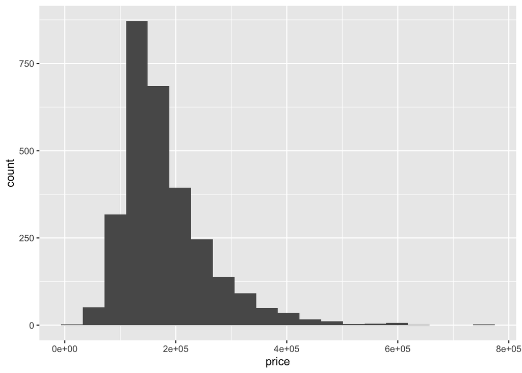

```r
Filtered_ames %>%
  ggplot(aes(x = price)) +
  geom_histogram(bins = 20)
```

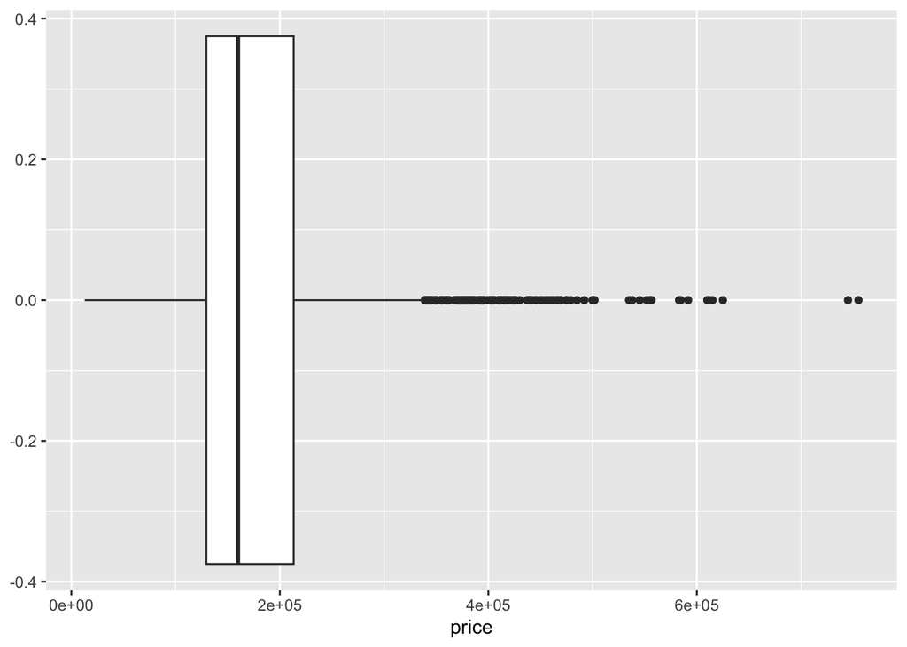

```r
Filtered_ames %>%
  ggplot(aes(x = price)) +
  geom_boxplot()
```